# Data Science Capstone - Exploratory Analysis

Marcus Turnbo

February 19, 2017

The purpose of this analysis is to:

1. Perform a thorough exploratory analysis of the data, understanding the distribution of words and relationship between the words in the corpora.
2. Build figures and tables to understand variation in the frequencies of words and word pairs in the data.

## Data acquisition & Cleaning

### Load data sets and get sizes and lengths

```r
setwd("../data/final/en_US")

twitter.us <- readLines("en_US.twitter.txt", encoding = "UTF-8", skipNul=TRUE)
twitter.us.size <- file.info("en_US.twitter.txt")$size / 1024 / 1024
twitter.us.length <- length(twitter.us)
twitter.us.words <- sum(sapply(gregexpr("\\S+", twitter.us), length))

news.us <- readLines("en_US.news.txt", encoding = "UTF-8", skipNul=TRUE)
news.us.size <- file.info("en_US.news.txt")$size / 1024 / 1024
news.us.length <- length(news.us)
news.us.words <- sum(sapply(gregexpr("\\S+", news.us), length))

blogs.us <- readLines("en_US.blogs.txt", encoding = "UTF-8", skipNul=TRUE)
blogs.us.size <- file.info("en_US.blogs.txt")$size / 1024 / 1024
blogs.us.length <- length(blogs.us)
blogs.us.words <- sum(sapply(gregexpr("\\S+", blogs.us), length))
```

### Twitter Dataset

159.364069 MB 2360148 lines 30373603 words

### News Dataset

196.2775126 MB 1010242 lines 34372530 words

### Blogs Dataset

200.4242077 MB 899288 lines 37334147 words

## Cleaning up the data

Using list of bad words from https://code.google.com/p/badwordslist/downloads/detail?name=badwords.txt

```r
setwd("../data/final/en_US")
badwords = readLines("badwords.txt")
```

### Tokenization

We will work with a sample of the data for tokenization.

```r
sample <- c(sample(twitter.us, 10000), sample(news.us, 10000), sample(blogs.us, 10000))
```

```r
corpus <- Corpus(VectorSource(sample))                  # build corpus
corpus <- tm_map(corpus, removeNumbers)                 # remove numbers
corpus <- tm_map(corpus, stripWhitespace)               # removing whitespace
corpus <- tm_map(corpus, removePunctuation)             # remove special characters
corpus <- tm_map(corpus, PlainTextDocument)
corpus <- tm_map(corpus, removeWords, badwords, lazy = TRUE)         # bad words
```

Use RWeka package to create one-word, two-word, and three-word tokenizations.

```r
cleanText <- data.frame(text=unlist(sapply(corpus, `[`, "content")), stringsAsFactors = FALSE)

unigrams <- NGramTokenizer(cleanText, Weka_control(min = 1, max = 1))
saveRDS(unigrams, file = "../data/final/en_US/sample_unigrams.rds")

bigrams <- NGramTokenizer(cleanText, Weka_control(min = 2, max = 2, delimiters = " \\r\\n\\t.,;:\"()?!"))
saveRDS(bigrams, file = "../data/final/en_US/sample_bigrams.rds")

trigrams <- NGramTokenizer(cleanText, Weka_control(min = 3, max = 3, delimiters = " \\r\\n\\t.,;:\"()?!"))
saveRDS(trigrams, file = "../data/final/en_US/sample_trigrams.rds")
```

## Exploratory Analysis

We analyze the distributions of words in the tokenizations by frequency.

```r
dfUniGrams <- data.frame(table(unigrams))
dfUniGrams <- dfUniGrams[order(dfUniGrams$Freq, decreasing=TRUE),]
colnames(dfUniGrams) <- c("Word", "Frequency")

dfBiGrams = data.frame(table(bigrams))
dfBiGrams <- dfBiGrams[order(dfBiGrams$Freq, decreasing=TRUE),]
colnames(dfBiGrams) <- c("Word", "Frequency")

dfTriGrams = data.frame(table(trigrams))
dfTriGrams <- dfTriGrams[order(dfTriGrams$Freq, decreasing=TRUE),]
colnames(dfTriGrams) <- c("Word", "Frequency")
```

### Top 20 One-Gram Terms (Sorted Alphabetically)

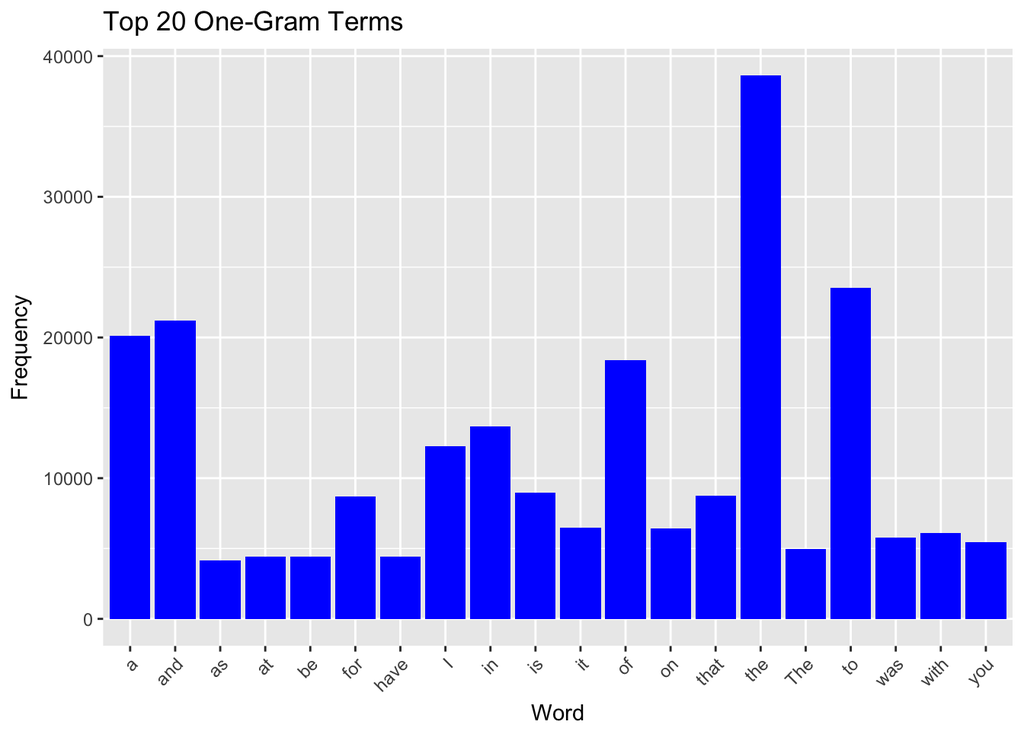

```r
ggplot(head(dfUniGrams, 20), aes(x=Word,y=Frequency)) +
  geom_bar(stat="Identity", fill="blue") +
  ggtitle("Top 20 One-Gram Terms") +
  theme(axis.text.x = element_text(angle=45, hjust=1))
```

### Top 20 BiGram Terms (Sorted Alphabetically)

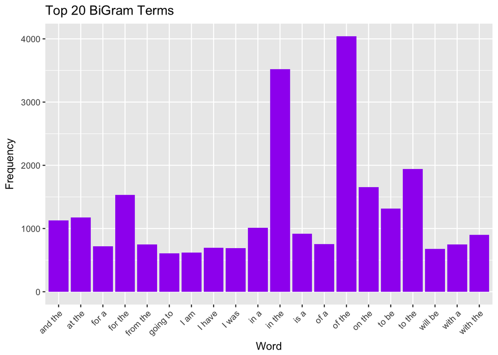

```r
ggplot(head(dfBiGrams, 20), aes(x=Word,y=Frequency)) +
  geom_bar(stat="Identity", fill="purple") +
  ggtitle("Top 20 BiGram Terms") +
  theme(axis.text.x = element_text(angle=45, hjust=1))
```

### Top 20 TriGram Terms (Sorted Alphabetically)

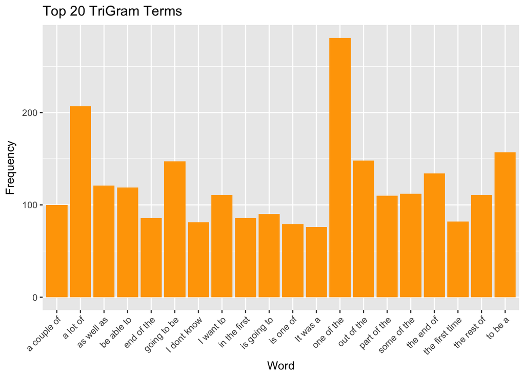

```r
ggplot(head(dfTriGrams, 20), aes(x=Word,y=Frequency)) +
  geom_bar(stat="Identity", fill="orange") +
  ggtitle("Top 20 TriGram Terms") +
  theme(axis.text.x = element_text(angle=45, hjust=1))
```

As we add more words to grams the frequencies became much lower. the number of combinations are much higher than number of words so the frequencies decreases.

## How many unique words do you need in a frequency sorted dictionary to cover 50% of all word instances in the language? 90%?

```r
wordCoverage <- function (words, coverage)
{
  frequency <- 0
  requiredFrequency <- coverage * sum(words$Frequency)
  for (i in 1:nrow(words)) {
    if (frequency >= requiredFrequency) {
      return (i)
    }
    frequency <- frequency + words$Frequency[i]
  }
}
```

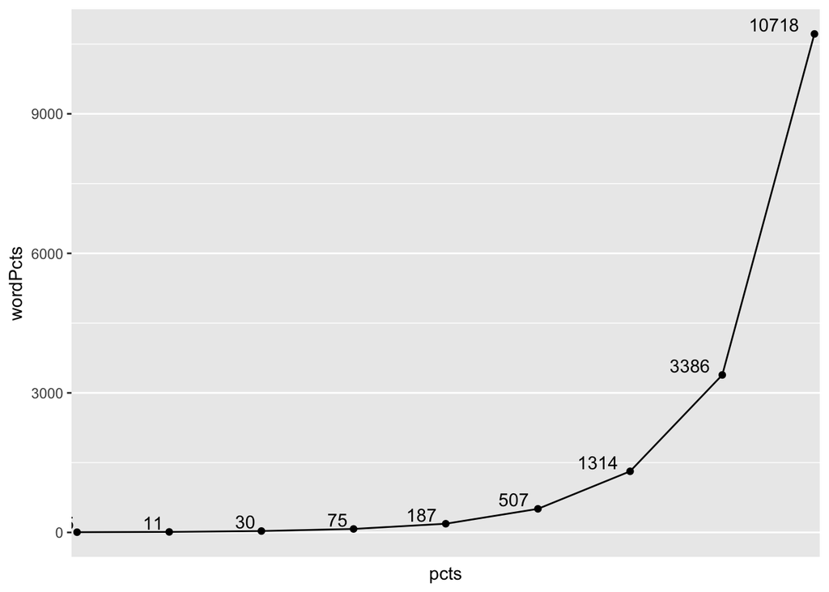

```r
pcts <- c(10, 20, 30, 40, 50, 60, 70, 80, 90)
wordPcts <- c()
for (p in pcts) {
  wordPcts <- c(wordPcts, wordCoverage(dfUniGrams, (p/100.0)))
}
qplot(pcts, wordPcts, geom=c("line","point")) + geom_text(aes(label=wordPcts), hjust=1.3, vjust=-0.2) +
  scale_x_discrete(breaks=pcts, labels=pcts)
```

## Future Plans for Prediction Algorithm

- Build functions to process the entire dataset
- Optimize number of entries in each n-gram for amount of computer memory